# Assignment 2: Spatial Analysis and Visualization

Healthcare Access and Equity in Pennsylvania

Author

Yuqing(Demi) Yang

Published

December 2, 2025

## Assignment Overview

**Learning Objectives:** - Apply spatial operations to answer policy-relevant research questions - Integrate census demographic data with spatial analysis - Create publication-quality visualizations and maps - Work with spatial data from multiple sources - Communicate findings effectively for policy audiences

## Part 1: Healthcare Access for Vulnerable Populations

### Research Question

- **Which Pennsylvania counties have the highest proportion of vulnerable populations (elderly + low-income) living far from hospitals?**

Your analysis should identify counties that should be priorities for healthcare investment and policy intervention.

### Required Analysis Steps

Complete the following analysis, documenting each step with code and brief explanations:

#### Step 1: Data Collection (5 points)

Load the required spatial data: - Pennsylvania county boundaries - Pennsylvania hospitals (from lecture data) - Pennsylvania census tracts

**Your Task:**

```r
# Load required packages

library(sf)
library(tidyverse)
library(tigris)
library(tidycensus)
library(scales)
library(patchwork)
library(here)
library(units)
library(kableExtra)
census_api_key("42bf8a20a3df1def380f330cf7edad0dd5842ce6")

# Load spatial data

options(tigris_progress = FALSE, tigris_use_cache = TRUE)
pa_counties <- st_read(here("assignments/assignment_2/data/Pennsylvania_County_Boundaries.shp"),quiet = TRUE)
hospitals <- st_read(here("assignments/assignment_2/data/hospitals.geojson"),quiet = TRUE)
census_tracts <- tracts(state = "PA", cb = TRUE)

# Check that all data loaded correctly

## 1)Make a table for checking

layers <- list(
  pa_counties   = pa_counties,
  hospitals     = hospitals,
  census_tracts = census_tracts
)

qc <- function(x) {
  data.frame(
    is_sf    = inherits(x, "sf"),
    n        = nrow(x),
    geom     = paste(unique(as.character(st_geometry_type(x))), collapse = ", "),
    crs_epsg = st_crs(x)$epsg,
    crs_txt  = st_crs(x)$input,
    invalid  = sum(!st_is_valid(x)),
    empty    = sum(st_is_empty(x)),
    bbox     = paste(round(st_bbox(x), 3), collapse = ", ")
  )
}

qc_table <- do.call(rbind, lapply(layers, qc)) %>%
  tibble::rownames_to_column("Layer")

kable(
  qc_table,
  caption = "Summary of Spatial Layers and Geometry Quality Checks",
  align = "c"
) %>%
  kable_styling(
    full_width = FALSE,
    bootstrap_options = c("striped", "hover", "condensed")
  )
```

Summary of Spatial Layers and Geometry Quality Checks

| Layer | is_sf | n | geom | crs_epsg | crs_txt | invalid | empty | bbox |
| --- | --- | --- | --- | --- | --- | --- | --- | --- |
| pa_counties | TRUE | 67 | MULTIPOLYGON | 3857 | WGS 84 / Pseudo-Mercator | 0 | 0 | -8963376.946, 4825316.222, -8314403.862, 5201412.518 |
| hospitals | TRUE | 223 | POINT | 4326 | WGS 84 | 0 | 0 | -80.496, 39.752, -74.867, 42.134 |
| census_tracts | TRUE | 3445 | MULTIPOLYGON | 4269 | NAD83 | 0 | 0 | -80.52, 39.72, -74.69, 42.27 |

**Questions to answer:**

- **How many hospitals are in your dataset?**
  - 223
- **How many census tracts?**
  - 3445
- **What coordinate reference system is each dataset in?**
  - *Pennsylvania county boundaries* is in EPSG:3857(WGS 84 / Web-Mercator, meters), *Pennsylvania hospitals* is in EPSG:4326(WGS 84 geographic, degrees), and *Pennsylvania census tracts* is in EPSG:4269(NAD83 geographic, degrees).

#### Step 2: Get Demographic Data

Use `tidycensus` to download tract-level demographic data for Pennsylvania.

**Required variables:** - Total population - Median household income - Population 65 years and over (you may need to sum multiple age categories)

**Your Task:**

```r
# Get demographic data from ACS

## 1)Reach the data
core_vars <- c(
  total_pop     = "B01003_001",
  median_income = "B19013_001"
)

acs_core <- get_acs(
  geography = "tract",
  state     = "PA",
  variables = core_vars,
  year      = 2022,
  survey    = "acs5",
  output    = "wide",
  geometry  = FALSE
) %>%
  transmute(
    GEOID,
    total_pop     = total_popE,
    median_income = median_incomeE
  )

## 2) Calculate the population 65 years and over
age65_vars <- c(sprintf("B01001_%03d", 20:25), sprintf("B01001_%03d", 44:49))

acs_65_wide <- get_acs(
  geography = "tract", state = "PA", variables = age65_vars,
  year = 2022, survey = "acs5"
) %>%
  select(GEOID, variable, estimate) %>%
  pivot_wider(names_from = variable, values_from = estimate)

acs_65plus <- acs_65_wide %>%
  mutate(
    non_na_bins = rowSums(!is.na(across(all_of(age65_vars)))),
    over65 = if_else(
      non_na_bins == 0, NA_real_,
      rowSums(across(all_of(age65_vars)), na.rm = TRUE)
    )
  ) %>%
  select(GEOID, over65)

# Join to tract boundaries
options(tigris_progress = FALSE, tigris_use_cache = TRUE)

pa_tracts <- tracts(state = "PA", year = 2022, cb = TRUE, class = "sf")

pa_tracts_joined <- pa_tracts %>%
  left_join(acs_core,   by = "GEOID") %>%
  left_join(acs_65plus, by = "GEOID") %>%
  mutate(
    over65_share = if_else(!is.na(total_pop) & total_pop > 0, over65 / total_pop, NA_real_)
  )

## 2) Count the missing data and medium data of income
income_na_n   <- sum(is.na(pa_tracts_joined$median_income))
income_median_overall <- median(pa_tracts_joined$median_income, na.rm = TRUE)

## 3) Remove missing values
pa_tracts_demo <- pa_tracts_joined %>%
  filter(!is.na(median_income), !is.na(over65_share))
```

**Questions to answer:**

- **What year of ACS data are you using?**
  - 2022
- **How many tracts have missing income data?**
  - 62. Mostly because household = 0, or household is extremely small.
- **What is the median income across all PA census tracts?**
  - 70188

#### Step 3: Define Vulnerable Populations

Identify census tracts with vulnerable populations based on TWO criteria: 1. Low median household income (choose an appropriate threshold) 2. Significant elderly population (choose an appropriate threshold)

**Your Task:**

```r
# Filter for vulnerable tracts based on your criteria

## 1) thresholds
income_threshold  <- quantile(pa_tracts_demo$median_income, 0.25, na.rm = TRUE, names = FALSE)
elderly_q75       <- quantile(pa_tracts_demo$over65_share, 0.75, na.rm = TRUE, names = FALSE)

## 2) flags + vulnerable
pa_tracts_demo <- pa_tracts_demo %>%
  mutate(
    low_income   = median_income <= income_threshold,
    high_elderly = over65_share >= elderly_q75,
    vulnerable   = low_income & high_elderly
  )

## 3) quick outputs
elderly_q75
```

```
[1] 0.2314351
```

```r
sum(pa_tracts_demo$vulnerable, na.rm = TRUE)
```

```
[1] 165
```

```r
round(mean(pa_tracts_demo$vulnerable, na.rm = TRUE) * 100, 1)
```

```
[1] 4.9
```

**Questions to answer:**

- **What income threshold did you choose and why?**
  - The low-income threshold = tract median income ≤ state 25th percentile.A percentile-based, within-state threshold is robust to outliers and gives a clear “most disadvantaged” group.
- **What elderly population threshold did you choose and why?**
  - The aging threshold = 65+ share ≥ state 75th percentile.Using percentile cutoffs to identify the “upper tail” aligns with screening practice.Both thresholds follow a percentile-ranking approach widely used by *federal screening tools (SVI/EJScreen)*.
- **How many tracts meet your vulnerability criteria?**
  - 165
- **What percentage of PA census tracts are considered vulnerable by your definition?**
  - 4.9%

#### Step 4: Calculate Distance to Hospitals

For each vulnerable tract, calculate the distance to the nearest hospital.

**Your Task:**

```r
# Transform to appropriate projected CRS

## 1) Copy and reproject (without modifying the original object)
distance_crs <- 5070
pa_tracts_demo_5070 <- st_transform(pa_tracts_demo, distance_crs)
hospitals_5070 <- st_transform(hospitals, distance_crs)

## 2) Keep only vulnerable tracts
vuln_5070 <- pa_tracts_demo_5070 %>%
  dplyr::filter(vulnerable %in% TRUE)

stopifnot(nrow(hospitals_5070) > 0)
stopifnot(nrow(vuln_5070) > 0)

# Calculate distance from each tract centroid to nearest hospital

## 1) Use an interior representative point
vuln_pts_5070 <- st_centroid(vuln_5070)

## 2) Pairwise distance matrix (meters)
dist_mat_m <- st_distance(vuln_pts_5070, hospitals_5070)

## 3) Distance: tract centroid -> nearest hospital
nearest_idx <- apply(dist_mat_m, 1, function(x) which.min(as.numeric(x)))
min_dist_m <- apply(dist_mat_m, 1, function(x) min(as.numeric(x), na.rm = TRUE))

## 4) meters → miles
dist_mi <- min_dist_m / 1609.344

## 5) Attach back to vulnerable tracts
vulnerable_tracts_dist_5070 <- vuln_5070 %>%
  mutate(
    nearest_hospital_row = nearest_idx,
    dist_to_hospital_mi  = dist_mi)


avg_dist_mi  <- mean(vulnerable_tracts_dist_5070$dist_to_hospital_mi, na.rm = TRUE)
max_dist_mi  <- max(vulnerable_tracts_dist_5070$dist_to_hospital_mi, na.rm = TRUE)
over15_count <- sum(vulnerable_tracts_dist_5070$dist_to_hospital_mi > 15, na.rm = TRUE)

cat(
  "Average distance to nearest hospital (miles): ", round(avg_dist_mi, 2), "\n",
  "Maximum distance (miles): ",                   round(max_dist_mi, 2), "\n",
  "Vulnerable tracts > 15 miles: ",               over15_count, "\n",
  sep = ""
)
```

```
Average distance to nearest hospital (miles): 4.75
Maximum distance (miles): 19.32
Vulnerable tracts > 15 miles: 10
```

**Requirements:**

- **Use an appropriate projected coordinate system for Pennsylvania**
- **Calculate distances in miles**
- **Explain why you chose your projection**
  - I use EPSG:5070 (NAD83 / Conus Albers) because it provides low distortion across the conterminous U.S., so distances computed statewide in Pennsylvania are much more reliable than in Web Mercator (distorts scale) or unprojected WGS84 (degrees). It also uses meters, making distance and area calculations straightforward, and it avoids zone-splitting issues you’d hit with StatePlane or UTM.

**Questions to answer:**

- **What is the average distance to the nearest hospital for vulnerable tracts?**
  - 4.75
- **What is the maximum distance?**
  - 19.32
- **How many vulnerable tracts are more than 15 miles from the nearest hospital?**
  - 10

#### Step 5: Identify Underserved Areas

Define “underserved” as vulnerable tracts that are more than 15 miles from the nearest hospital.

**Your Task:**

```r
# Create underserved variable

vulnerable_tracts_dist_5070 <- vulnerable_tracts_dist_5070 %>%
  dplyr::mutate(underserved = dist_to_hospital_mi > 15)


sum(vulnerable_tracts_dist_5070$underserved, na.rm = TRUE)
```

```
[1] 10
```

```r
round(mean(vulnerable_tracts_dist_5070$underserved, na.rm = TRUE) * 100, 1)
```

```
[1] 6.1
```

**Questions to answer:**

- **How many tracts are underserved?**
  - 10
- **What percentage of vulnerable tracts are underserved?**
  - 6.1%
- **Does this surprise you? Why or why not?**
  - Hospitals cluster in metro areas, so it’s expected that some rural, low-density tracts fall farther from facilities; under my definition, only ~6% of vulnerable tracts are underserved, which suggests overall access is fairly good. That said, pockets of concern remain, and distance alone doesn’t capture barriers like transportation or service capacity.

#### Step 6: Aggregate to County Level

Use spatial joins and aggregation to calculate county-level statistics about vulnerable populations and hospital access.

**Your Task:**

```r
# Spatial join tracts to counties

pa_counties_5070 <- st_transform(pa_counties, 5070)

vuln_with_county <- vulnerable_tracts_dist_5070 %>%
  st_join(pa_counties_5070 %>% select(COUNTY_NAM))

# Aggregate statistics by county

county_summary <- vuln_with_county %>%
  st_drop_geometry() %>%
  group_by(COUNTY_NAM) %>%
  summarise(
    vulnerable_tracts          = n(),
    underserved_tracts         = sum(underserved, na.rm = TRUE),
    pct_underserved            = 100 * underserved_tracts / vulnerable_tracts,
    avg_dist_mi_vulnerable     = mean(dist_to_hospital_mi, na.rm = TRUE),
    vulnerable_population      = sum(total_pop, na.rm = TRUE),
    vulnerable_pop_far_mi15    = sum(ifelse(underserved, total_pop, 0), na.rm = TRUE),
    .groups = "drop")
```

```r
county_summary %>%
  arrange(desc(pct_underserved)) %>%
  select(COUNTY_NAM, vulnerable_tracts, underserved_tracts, pct_underserved) %>%
  slice_head(n = 5)
```

```
# A tibble: 5 × 4
  COUNTY_NAM vulnerable_tracts underserved_tracts pct_underserved
  <chr>                  <int>              <int>           <dbl>
1 BRADFORD                   1                  1             100
2 COLUMBIA                   1                  1             100
3 JUNIATA                    1                  1             100
4 MONROE                     1                  1             100
5 PERRY                      2                  2             100
```

```r
county_summary %>%
  arrange(desc(vulnerable_pop_far_mi15)) %>%
  select(COUNTY_NAM, vulnerable_population, vulnerable_pop_far_mi15) %>%
  slice_head(n = 5)
```

```
# A tibble: 5 × 3
  COUNTY_NAM     vulnerable_population vulnerable_pop_far_mi15
  <chr>                          <dbl>                   <dbl>
1 PERRY                           5800                    5800
2 BRADFORD                        5466                    5466
3 CLEARFIELD                     16232                    5189
4 DAUPHIN                         8410                    4018
5 NORTHUMBERLAND                 13105                    4018
```

**Required county-level statistics:**

- Number of vulnerable tracts
- Number of underserved tracts
- Percentage of vulnerable tracts that are underserved
- Average distance to nearest hospital for vulnerable tracts
- Total vulnerable population

**Questions to answer:**

- **Which 5 counties have the highest percentage of underserved vulnerable tracts?**
  - BRADFORD,COLUMBIA,JUNIATA,MONROE,PERRY
- **Which counties have the most vulnerable people living far from hospitals?**
  - PERRY(5800),BRADFORD(5466),CLEARFIELD(5189),DAUPHIN(4018),NORTHUMBERLAND(4018)
- **Are there any patterns in where underserved counties are located?**
  - Underserved counties tend to cluster in rural and lower-density parts of Pennsylvania, where hospital coverage is sparse and facilities are concentrated in metro hubs. You’ll often see higher shares along the northern/central rural corridor and Appalachian areas, reflecting longer travel distances and thinner provider networks relative to population.

#### Step 7: Create Summary Table

Create a professional table showing the top 10 priority counties for healthcare investment.

**Your Task:**

```r
# Create and format priority counties table

priority_tbl <- county_summary %>%
  mutate(
    # safety: replace any NAs used in scoring
    across(c(vulnerable_pop_far_mi15, pct_underserved, avg_dist_mi_vulnerable,
             vulnerable_population, vulnerable_tracts, underserved_tracts),
           ~ tidyr::replace_na(., 0)),
    # Priority metric
    priority_score = 0.60 * rescale(vulnerable_pop_far_mi15) +
                     0.25 * rescale(pct_underserved) +
                     0.15 * rescale(avg_dist_mi_vulnerable)
  ) %>%
  arrange(desc(priority_score)) %>%
  slice_head(n = 10) %>%
  transmute(
    County                         = COUNTY_NAM,
    `Vulnerable tracts`            = vulnerable_tracts,
    `Underserved tracts`           = underserved_tracts,
    `% vulnerable underserved`     = percent(pct_underserved / 100, accuracy = 0.1),
    `Avg distance (mi)`            = number(avg_dist_mi_vulnerable, accuracy = 0.1),
    `Vulnerable people >15 mi`     = comma(vulnerable_pop_far_mi15),
    `Priority score`               = number(priority_score, accuracy = 0.01)
  )

# Nicely formatted table
knitr::kable(
  priority_tbl,
  caption = "Top 10 Priority Pennsylvania Counties for Healthcare Investment
  (Priority Score weights: 60% vulnerable people >15 mi, 25% % vulnerable underserved, 15% average distance)",
  booktabs = TRUE
) |>
  kableExtra::kable_styling(full_width = FALSE, font_size = 12)
```

Top 10 Priority Pennsylvania Counties for Healthcare Investment (Priority Score weights: 60% vulnerable people >15 mi, 25% % vulnerable underserved, 15% average distance)

| County | Vulnerable tracts | Underserved tracts | % vulnerable underserved | Avg distance (mi) | Vulnerable people >15 mi | Priority score |
| --- | --- | --- | --- | --- | --- | --- |
| PERRY | 2 | 2 | 100.0% | 17.7 | 5,800 | 1.00 |
| BRADFORD | 1 | 1 | 100.0% | 16.7 | 5,466 | 0.96 |
| CLEARFIELD | 5 | 2 | 40.0% | 10.1 | 5,189 | 0.72 |
| DAUPHIN | 2 | 1 | 50.0% | 10.0 | 4,018 | 0.62 |
| NORTHUMBERLAND | 5 | 1 | 20.0% | 12.8 | 4,018 | 0.57 |
| JUNIATA | 1 | 1 | 100.0% | 16.0 | 1,782 | 0.57 |
| MONROE | 1 | 1 | 100.0% | 17.6 | 1,299 | 0.53 |
| FOREST | 2 | 1 | 50.0% | 15.2 | 2,701 | 0.53 |
| ELK | 4 | 1 | 25.0% | 11.0 | 3,343 | 0.50 |
| COLUMBIA | 1 | 1 | 100.0% | 16.9 | 918 | 0.49 |

**Requirements:** - Use `knitr::kable()` or similar for formatting - Include descriptive column names - Format numbers appropriately (commas for population, percentages, etc.) - Add an informative caption - Sort by priority (you decide the metric)

## Part 2: Comprehensive Visualization

Using the skills from Week 3 (Data Visualization), create publication-quality maps and charts.

### Map 1: County-Level Choropleth

Create a choropleth map showing healthcare access challenges at the county level.

**Your Task:**

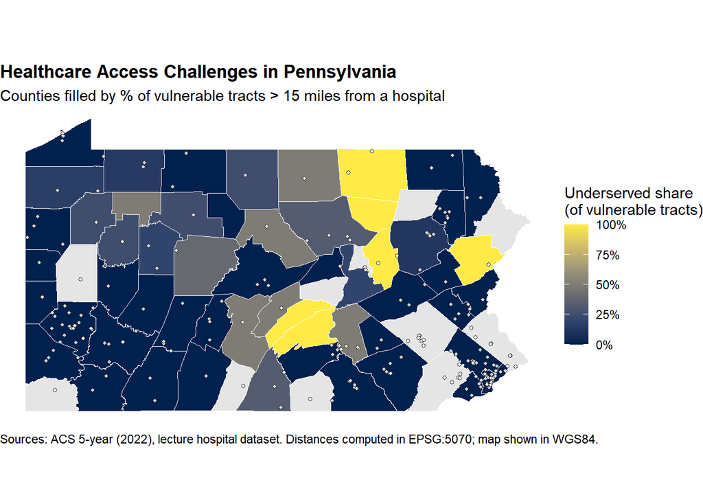

```r
# Create county-level access map

# 1) Reproject display layers to WGS84 (EPSG:4326)
crs_display <- 4326
pa_counties_4326 <- st_transform(pa_counties, crs_display)
hospitals_4326   <- st_transform(hospitals, crs_display)

# 2) Join county stats to county geometries
county_map_4326 <- pa_counties_4326 %>%
  left_join(
    county_summary %>%
      mutate(pct_underserved_prop = pct_underserved / 100),
    by = "COUNTY_NAM"
  )

# 3) Choropleth (WGS84) + hospital points
ggplot(county_map_4326) +
  geom_sf(aes(fill = pct_underserved_prop), color = "white", linewidth = 0.2) +
  geom_sf(data = hospitals_4326, shape = 21, fill = "white", color = "black",
          size = 1.1, alpha = 0.8, inherit.aes = FALSE) +
  scale_fill_viridis_c(
    option = "cividis",
    na.value = "grey90",
    name = "Underserved share\n(of vulnerable tracts)",
    labels = label_percent(accuracy = 1)
  ) +
  labs(
    title    = "Healthcare Access Challenges in Pennsylvania",
    subtitle = "Counties filled by % of vulnerable tracts > 15 miles from a hospital",
    caption  = "Sources: ACS 5-year (2022), lecture hospital dataset. Distances computed in EPSG:5070; map shown in WGS84."
  ) +
  theme_void() +
  theme(
    legend.position = "right",
    plot.title      = element_text(face = "bold"),
    plot.caption    = element_text(hjust = 0)
  )
```

**Requirements:** - Fill counties by percentage of vulnerable tracts that are underserved - Include hospital locations as points - Use an appropriate color scheme - Include clear title, subtitle, and caption - Use `theme_void()` or similar clean theme - Add a legend with formatted labels

### Map 2: Detailed Vulnerability Map

Create a map highlighting underserved vulnerable tracts.

**Your Task:**

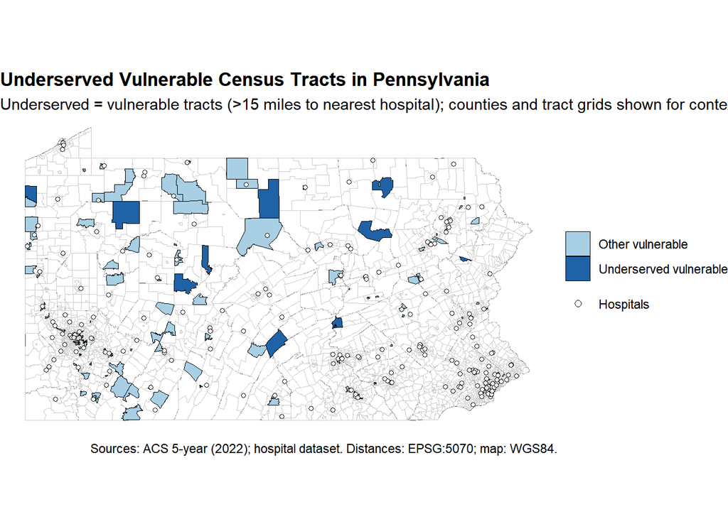

```r
# Create detailed tract-level map

## 1)Ensure "underserved" exists; keep only vulnerable tracts and make a status label
vuln_dist_4326 <- vulnerable_tracts_dist_5070 %>%
  mutate(underserved = if (!"underserved" %in% names(.)) dist_to_hospital_mi > 15 else underserved) %>%
  st_transform(crs_display) %>%
  mutate(
    status = ifelse(underserved, "Underserved vulnerable", "Other vulnerable")
  )

## 2)Map
tracts_4326 <- sf::st_transform(census_tracts, 4326)
ggplot() +
  # county boundaries (context; subtle)
  geom_sf(data = pa_counties_4326, fill = NA, color = "grey40", linewidth = 0.3) +

  # tracts
  geom_sf(data = tracts_4326, fill = NA, color = "grey80", linewidth = 0.05) +

  # vulnerable tracts
  geom_sf(data = subset(vuln_dist_4326, status == "Other vulnerable"),
  aes(fill = status), color = "black", linewidth = 0.15, alpha = 0.9) +

  # underserved vulnerable tracts
  geom_sf(data = subset(vuln_dist_4326, status == "Underserved vulnerable"),
  aes(fill = status), color = "black", linewidth = 0.15, alpha = 0.9) +

  # hospitals (points)
  geom_sf(
  data = hospitals_4326,
  aes(shape = "Hospitals"),
  fill = "white", color = "black",
  size = 1.2, alpha = 0.9,
  inherit.aes = FALSE,
  show.legend = "point"
) +

  # fills for tracts
  scale_fill_manual(
    name = NULL,
    values = c("Other vulnerable" = "#9ecae1", "Underserved vulnerable" = "#08519c")
  ) +
  # shape for hospitals + legend tweaks
  scale_shape_manual(name = NULL, values = c("Hospitals" = 21)) +
  guides(
    fill  = guide_legend(order = 1, override.aes = list(shape = NA)),
    shape = guide_legend(order = 2, override.aes = list(fill = "white", color = "black", size = 2))
  ) +
  labs(
    title    = "Underserved Vulnerable Census Tracts in Pennsylvania",
    subtitle = "Underserved = vulnerable tracts (>15 miles to nearest hospital); counties and tract grids shown for context",
    caption  = "Sources: ACS 5-year (2022); hospital dataset. Distances: EPSG:5070; map: WGS84."
  ) +
  theme_void() +
  theme(legend.position = "right", plot.title = element_text(face = "bold"))
```

**Requirements:**

- Show underserved vulnerable tracts in a contrasting color
- Include county boundaries for context
- Show hospital locations
- Use appropriate visual hierarchy (what should stand out?)
- Include informative title and subtitle

### Chart: Distribution Analysis

Create a visualization showing the distribution of distances to hospitals for vulnerable populations.

**Your Task:**

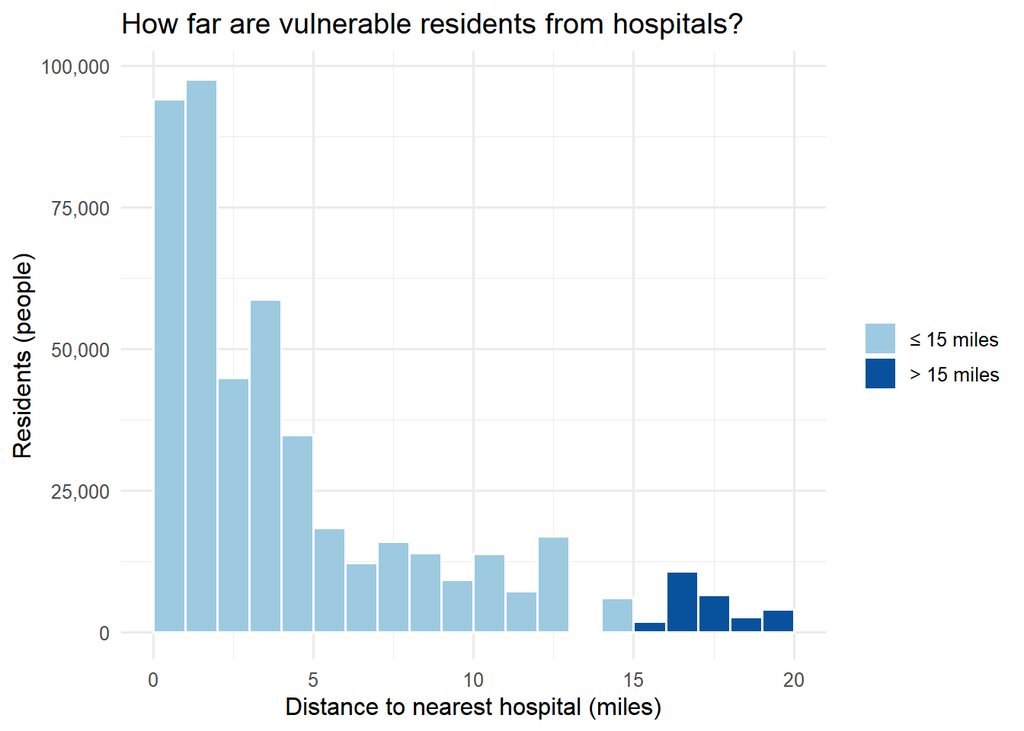

```r
# Create distribution visualization

## A small helper used in captions
median_dist <- median(vulnerable_tracts_dist_5070$dist_to_hospital_mi, na.rm = TRUE)

## 1) People-weighted histogram of distances (highlighting the 15-mile threshold)
vulnerable_tracts_dist_5070 |>
  mutate(beyond15 = factor(dist_to_hospital_mi > 15,
                           levels = c(FALSE, TRUE),
                           labels = c("≤ 15 miles", "> 15 miles"))) |>
  ggplot(aes(x = dist_to_hospital_mi, weight = total_pop, fill = beyond15)) +
  geom_histogram(binwidth = 1, boundary = 0, color = "white") +
  scale_fill_manual(values = c("≤ 15 miles" = "#9ecae1", "> 15 miles" = "#08519c"),
                    name = NULL) +
  scale_y_continuous(labels = comma) +
  labs(
    title = "How far are vulnerable residents from hospitals?",
    x = "Distance to nearest hospital (miles)",
    y = "Residents (people)"
  ) +
  theme_minimal(base_size = 12) +
  theme(legend.position = "right")
```

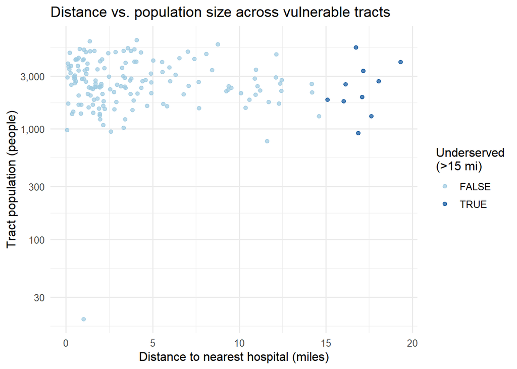

```r
# 2) Scatter: Distance vs. tract population (vulnerable tracts)
ggplot(vulnerable_tracts_dist_5070,
       aes(x = dist_to_hospital_mi, y = total_pop, color = underserved)) +
  geom_point(alpha = 0.7) +
  scale_y_continuous(labels = comma, trans = "log10") +
  scale_color_manual(values = c(`FALSE` = "#9ecae1", `TRUE` = "#08519c"),
                     name = "Underserved\n(>15 mi)") +
  labs(
    title = "Distance vs. population size across vulnerable tracts",
    x = "Distance to nearest hospital (miles)",
    y = "Tract population (people)"
  ) +
  theme_minimal(base_size = 12) +
  theme(legend.position = "right")
```

**Suggested chart types:**

- Histogram or density plot of distances
- Box plot comparing distances across regions
- Bar chart of underserved tracts by county
- Scatter plot of distance vs. vulnerable population size

**Requirements:**

## Part 3: Bring Your Own Data Analysis

Choose your own additional spatial dataset and conduct a supplementary analysis.

### Challenge Options

Choose ONE of the following challenge exercises, or propose your own research question using OpenDataPhilly data (https://opendataphilly.org/datasets/).

#### Education & Youth Services

**Option A: Educational Desert Analysis** - **Data:** Schools, Libraries, Recreation Centers, Census tracts (child population) - **Question:** “Which neighborhoods lack adequate educational infrastructure for children?” - **Operations:** Buffer schools/libraries (0.5 mile walking distance), identify coverage gaps, overlay with child population density - **Policy relevance:** School district planning, library placement, after-school program siting

**Option B: School Safety Zones** - **Data:** Schools, Crime Incidents, Bike Network - **Question:** “Are school zones safe for walking/biking, or are they crime hotspots?” - **Operations:** Buffer schools (1000ft safety zone),spatial join with crime incidents, assess bike infrastructure coverage - **Policy relevance:** Safe Routes to School programs, crossing guard placement

#### Environmental Justice

**Option C: Green Space Equity** - **Data:** Parks, Street Trees, Census tracts (race/income demographics) - **Question:** “Do low-income and minority neighborhoods have equitable access to green space?” - **Operations:** Buffer parks (10-minute walk = 0.5 mile), calculate tree canopy or park acreage per capita, compare by demographics - **Policy relevance:** Climate resilience, environmental justice, urban forestry investment —

#### Public Safety & Justice

**Option D: Crime & Community Resources** - **Data:** Crime Incidents, Recreation Centers, Libraries, Street Lights - **Question:** “Are high-crime areas underserved by community resources?” - **Operations:** Aggregate crime counts to census tracts or neighborhoods, count community resources per area, spatial correlation analysis - **Policy relevance:** Community investment, violence prevention strategies —

#### Infrastructure & Services

**Option E: Polling Place Accessibility** - **Data:** Polling Places, SEPTA stops, Census tracts (elderly population, disability rates) - **Question:** “Are polling places accessible for elderly and disabled voters?” - **Operations:** Buffer polling places and transit stops, identify vulnerable populations, find areas lacking access - **Policy relevance:** Voting rights, election infrastructure, ADA compliance

#### Health & Wellness

**Option F: Recreation & Population Health** - **Data:** Recreation Centers, Playgrounds, Parks, Census tracts (demographics) - **Question:** “Is lack of recreation access associated with vulnerable populations?” - **Operations:** Calculate recreation facilities per capita by neighborhood, buffer facilities for walking access, overlay with demographic indicators - **Policy relevance:** Public health investment, recreation programming, obesity prevention

#### Emergency Services

**Option G: EMS Response Coverage** - **Data:** Fire Stations, EMS stations, Population density, High-rise buildings - **Question:** “Are population-dense areas adequately covered by emergency services?” - **Operations:** Create service area buffers (5-minute drive = ~2 miles), assess population coverage, identify gaps in high-density areas - **Policy relevance:** Emergency preparedness, station siting decisions

#### Arts & Culture

**Option H: Cultural Asset Distribution** - **Data:** Public Art, Museums, Historic sites/markers, Neighborhoods - **Question:** “Do all neighborhoods have equitable access to cultural amenities?” - **Operations:** Count cultural assets per neighborhood, normalize by population, compare distribution across demographic groups - **Policy relevance:** Cultural equity, tourism, quality of life, neighborhood identity

### Data Sources

**OpenDataPhilly:** https://opendataphilly.org/datasets/ - Most datasets available as GeoJSON, Shapefile, or CSV with coordinates - Always check the Metadata for a data dictionary of the fields.

**Additional Sources:** - **Pennsylvania Open Data:** https://data.pa.gov/ - **Census Bureau (via tidycensus):** Demographics, economic indicators, commute patterns - **TIGER/Line (via tigris):** Geographic boundaries

### Recommended Starting Points

**If you’re feeling confident:** Choose an advanced challenge with multiple data layers. **If you are a beginner, choose something more manageable that helps you understand the basics**

**If you have a different idea:** Propose your own question! Just make sure: - You can access the spatial data - You can perform at least 2 spatial operations